# Forecasting elections of US2020

Xu Xinyi 1003941577, Minchen Cai 1000523800, Haona Yang 1004949531, Mingkai Zhang 1004903063

2020/10/31

# Forecasting elections of US2020

## Xu Xinyi, Minchen Cai, Haona Yang, Mingkai Zhang

## 2020/10/31

# Model

## Model Specifics

I fit a multilevel logistic regression, which is used to model a binary dependent variable, to predict the voting support for Donald Trump and Joe Biden. I use age as a numeric variable, gender and hispanic as dummy variables, to model the probability of voting for both candidates. The model is given by:

$$p(Yi = Donald \ Trump | state_j) = logit^{-1}(\beta_{j0} + \beta_{ji}^{age} + b_{[i]}^{gender} + b_{[i]}^{hispanic})$$

$\beta_{j0}$ represents the baseline intercept of the variable in group j. Here group j stands for the level 2 variable of state. $\beta_{j1}$ represents the slope for voters’ age fraction among all voters in each state. When the respondent’s state changes, the coefficient of both the intercept and the slope will be varying as well. Moreover, each categorical variable is represented as dummy variables and corresponds to the changing coefficients. $b_{[i]}^{gender}$ represents female and male and $b_{[i]}^{hispanic})$ represents dummy variables for Cuban, Mexican, Not hispanic, Other hispanic and Puerto Rican respectively.

```
## Generalized linear mixed model fit by maximum likelihood (Laplace
##   Approximation) [glmerMod]
##  Family: binomial  ( logit )
## Formula: vote_trump ~ (1 + age | state) + gender + hispanic
##    Data: futher_survey_cleaning
##
##      AIC      BIC   logLik deviance df.resid
##   7325.4   7391.4  -3652.7   7305.4     5440
##
## Scaled residuals:
##     Min      1Q  Median      3Q     Max
## -1.8133 -0.8902 -0.6407  0.9939  2.0686
##
## Random effects:
##  Groups Name        Variance  Std.Dev. Corr
##  state  (Intercept) 0.1827446 0.42749
##         age         0.0001432 0.01197  -0.90
## Number of obs: 5450, groups:  state, 51
##
## Fixed effects:
##                        Estimate Std. Error z value Pr(>|z|)
## (Intercept)            -0.09795    0.64679  -0.151    0.880
## genderMale              0.52623    0.05674   9.275   <2e-16 ***
## hispanicCuban           0.33886    0.75675   0.448    0.654
## hispanicMexican        -0.99562    0.65021  -1.531    0.126
## hispanicNot Hispanic   -0.35737    0.64327  -0.556    0.579
## hispanicOther Hispanic -0.55955    0.65625  -0.853    0.394
## hispanicPuerto Rican   -1.10647    1.40415  -0.788    0.431
## ---
## Signif. codes:  0 '***' 0.001 '**' 0.01 '*' 0.05 '.' 0.1 ' ' 1
##
## Correlation of Fixed Effects:
##             (Intr) gndrMl hspncC hspncM hspnNH hspnOH
## genderMale  -0.021
## hispanicCbn -0.841  0.011
## hispancMxcn -0.981 -0.015  0.837
## hspncNtHspn -0.992 -0.024  0.846  0.986
## hspncOthrHs -0.971 -0.007  0.830  0.966  0.976
## hspncPrtRcn -0.454 -0.019  0.388  0.451  0.457  0.447
## optimizer (Nelder_Mead) convergence code: 0 (OK)
## Model is nearly unidentifiable: very large eigenvalue
##  - Rescale variables?
## Model is nearly unidentifiable: large eigenvalue ratio
##  - Rescale variables?
```

```
## Generalized linear mixed model fit by maximum likelihood (Laplace
##   Approximation) [glmerMod]
##  Family: binomial  ( logit )
## Formula: vote_biden ~ (1 + age | state) + gender + hispanic
##    Data: futher_survey_cleaning
##
##      AIC      BIC   logLik deviance df.resid
##   7397.1   7463.2  -3688.6   7377.1     5440
##
## Scaled residuals:
##     Min      1Q  Median      3Q     Max
## -1.7121 -0.9339 -0.5776  0.9516  1.8132
##
## Random effects:
##  Groups Name        Variance  Std.Dev. Corr
##  state  (Intercept) 1.017e-01 0.318928
##         age         8.495e-05 0.009217 -0.80
## Number of obs: 5450, groups:  state, 51
##
## Fixed effects:
##                        Estimate Std. Error z value Pr(>|z|)
## (Intercept)            -0.33332    0.65762  -0.507   0.6123
## genderMale             -0.51810    0.05628  -9.206   <2e-16 ***
## hispanicCuban          -0.12874    0.77026  -0.167   0.8673
## hispanicMexican         1.08917    0.66187   1.646   0.0998 .
## hispanicNot Hispanic    0.57067    0.65583   0.870   0.3842
## hispanicOther Hispanic  0.81303    0.66822   1.217   0.2237
## hispanicPuerto Rican    1.45515    1.40743   1.034   0.3012
## ---
## Signif. codes:  0 '***' 0.001 '**' 0.01 '*' 0.05 '.' 0.1 ' ' 1
##
## Correlation of Fixed Effects:
##             (Intr) gndrMl hspncC hspncM hspnNH hspnOH
## genderMale  -0.019
## hispanicCbn -0.844  0.010
## hispancMxcn -0.985 -0.014  0.840
## hspncNtHspn -0.995 -0.024  0.848  0.987
## hspncOthrHs -0.975 -0.007  0.833  0.969  0.978
## hspncPrtRcn -0.463 -0.018  0.397  0.460  0.465  0.456
## optimizer (Nelder_Mead) convergence code: 0 (OK)
## Model failed to converge with max|grad| = 0.00372646 (tol = 0.002, component 1)
## Model is nearly unidentifiable: very large eigenvalue
##  - Rescale variables?
## Model is nearly unidentifiable: large eigenvalue ratio
##  - Rescale variables?
```

|  | vote trump |  |  |
| --- | --- | --- | --- |
| Predictors | Odds Ratios | CI | p |
| (Intercept) | 0.91 | 0.26 – 3.22 | 0.880 |
| gender [Male] | 1.69 | 1.51 – 1.89 | **<0.001** |
| hispanic [Cuban] | 1.40 | 0.32 – 6.18 | 0.654 |
| hispanic [Mexican] | 0.37 | 0.10 – 1.32 | 0.126 |
| hispanic [Not Hispanic] | 0.70 | 0.20 – 2.47 | 0.579 |
| hispanic [Other Hispanic] | 0.57 | 0.16 – 2.07 | 0.394 |
| hispanic [Puerto Rican] | 0.33 | 0.02 – 5.18 | 0.431 |
| Random Effects |  |  |  |
| σ<sup>2</sup> | 3.29 |  |  |
| τ<sub>00</sub> <sub>state</sub> | 0.18 |  |  |
| τ<sub>11</sub> <sub>state.age</sub> | 0.00 |  |  |
| ρ<sub>01</sub> <sub>state</sub> | -0.90 |  |  |
| ICC | 0.05 |  |  |
| N <sub>state</sub> | 51 |  |  |
| Observations | 5450 |  |  |
| Marginal R<sup>2</sup> / Conditional R<sup>2</sup> | 0.032 / 0.083 |  |  |

|  | vote biden |  |  |
| --- | --- | --- | --- |
| Predictors | Odds Ratios | CI | p |
| (Intercept) | 0.72 | 0.20 – 2.60 | 0.612 |
| gender [Male] | 0.60 | 0.53 – 0.67 | **<0.001** |
| hispanic [Cuban] | 0.88 | 0.19 – 3.98 | 0.867 |
| hispanic [Mexican] | 2.97 | 0.81 – 10.87 | 0.100 |
| hispanic [Not Hispanic] | 1.77 | 0.49 – 6.40 | 0.384 |
| hispanic [Other Hispanic] | 2.25 | 0.61 – 8.35 | 0.224 |
| hispanic [Puerto Rican] | 4.29 | 0.27 – 67.60 | 0.301 |
| Random Effects |  |  |  |
| σ<sup>2</sup> | 3.29 |  |  |
| τ<sub>00</sub> <sub>state</sub> | 0.10 |  |  |
| τ<sub>11</sub> <sub>state.age</sub> | 0.00 |  |  |
| ρ<sub>01</sub> <sub>state</sub> | -0.80 |  |  |
| ICC | 0.03 |  |  |
| N <sub>state</sub> | 51 |  |  |
| Observations | 5450 |  |  |
| Marginal R<sup>2</sup> / Conditional R<sup>2</sup> | 0.029 / 0.058 |  |  |

## Post-Stratification

We use our multilevel regression model to predict the response voting rate for Trump or Biden in each state. Post stratification is a popular statistical technique to correct estimates when there are known differences between target population and study population. By applying post stratification to our census data, first all of is to partition the population into groups based on different attributes. Then, we may use samples to estimate the response variable in each group. Finally, it’s time to aggregate group level values by weighting each group by its corresponding proportion in population. In our model we grouped the population by their states, because the geographic location can influence an individual’s voting preferences. Then, we are interested in individuals’ voting intent and within each state we have 3 different variables: age, gender, and hispanic. We are able to predict a certain age group of female or male, that is considered to be a certain type of hispanic their preference in voting. Furthermore, by summing up all the outcomes over the entire population we are able to forecast the voting preference by this specific group of individuals.

| trump_na_pre |
| --- |
| 0.4673645 |

| biden_na_pre |
| --- |
| 0.4919032 |

| trump_pre |
| --- |
| 0.4423359 |

| biden_pre |
| --- |
| 0.5214624 |

| winner | total_votes |
| --- | --- |
| Donald Trump | 87 |
| Joe Biden | 451 |

| winner | total_votes |
| --- | --- |
| Donald Trump | 115 |
| Joe Biden | 423 |

```
## [1] 0.2137546
```

```
## [1] 0.7862454
```

```
## Rows: 5
## Columns: 4
## $ hispanic <chr> "Cuban", "Mexican", "Not Hispanic", "Other Hispanic", "Puert…
## $ Trump    <dbl> 360526, 87209, 2241954, 253491, 1471
## $ Biden    <dbl> 9561, 1563711, 3335231, 1482586, 82800
## $ winner   <chr> "Donald Trump", "Joe Biden", "Joe Biden", "Joe Biden", "Joe …
```

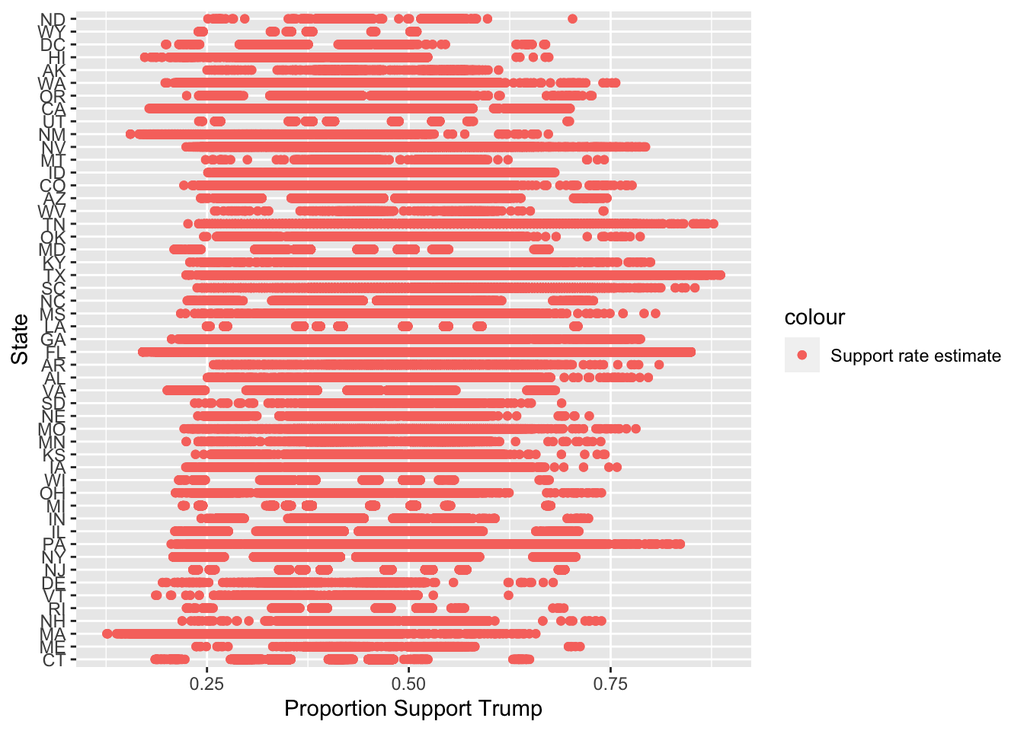

[figure not shown]

[figure not shown]